# Perturbation Theory for Constrained Optimal Control and Markov Decision Processes

Fast Algorithms for Dynamic Systems Under Continuous Perturbations

**Abhishek Gupta**

Associate Professor & Graduate Studies Chair, ECE  
Co-Director, IITB-OSU Frontier Center  
The Ohio State University  
Cofounder, Embraxis.ai

## Foundational theory for decisions that scale

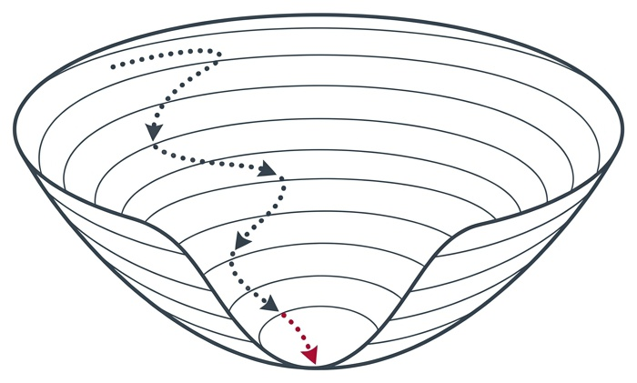

Theory

**Reinforcement Learning & Control:** New mathematical convergence techniques for infinite dimensional MDPs.

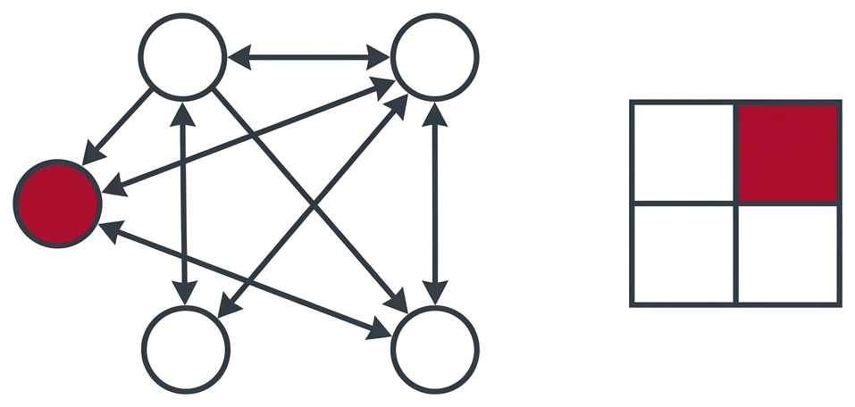

Theory

**Game Theory & Multi-Agent Systems:** Tractable solutions for decentralized teams and bimatrix games.

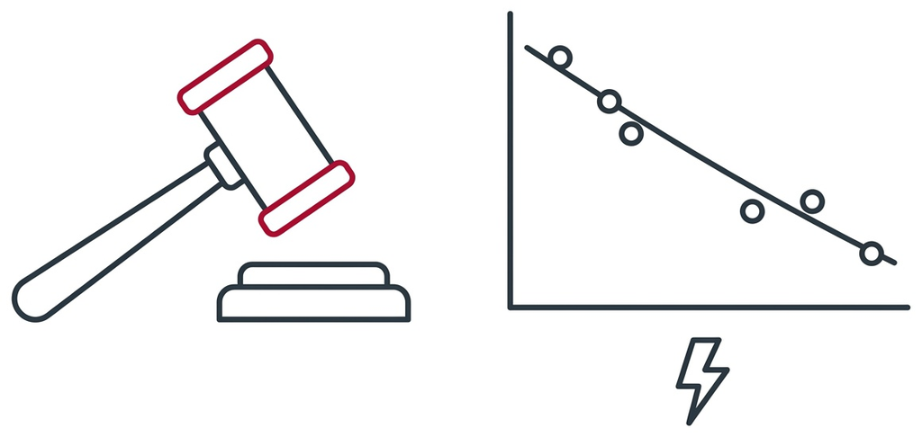

Theory

**Mechanism Design & Pricing:** Truthful auctions and dynamic pricing for electricity and transportation markets.

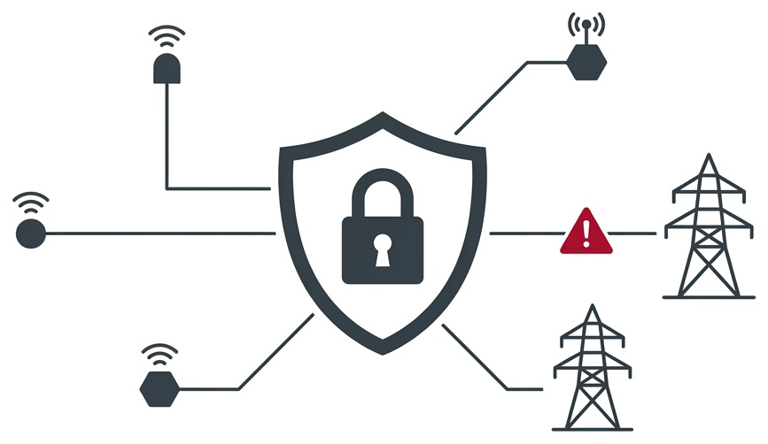

Application

**Cyberphysical Security:** Dynamic watermarking and game-theoretic defenses that protect networked systems from intelligent adversaries.

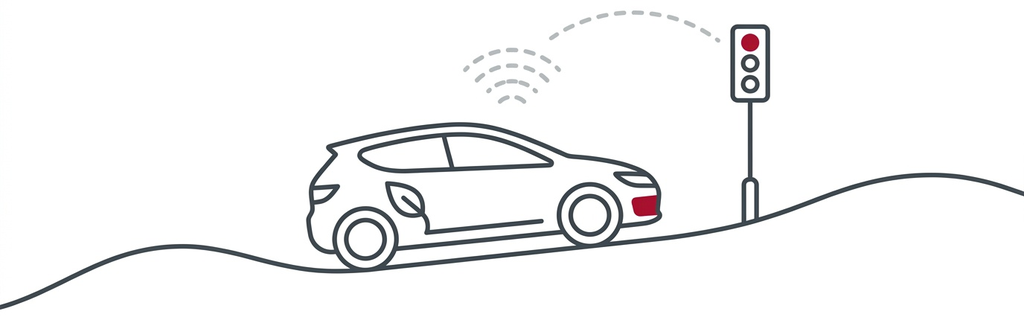

Application

**Transportation & Autonomy:** Deep RL and approximate DP for eco-driving in connected hybrid electric vehicles.

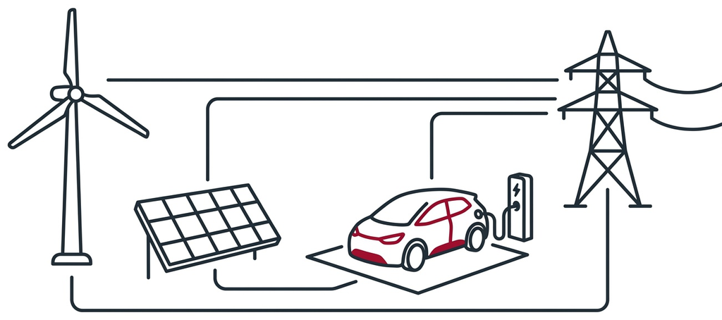

Application

**Energy Grids:** Market mechanisms and EV-charge scheduling algorithms for deep renewable integration.

# Part I · Perturbations in Dynamic Decision Process

## The Challenge: High-Dimensional Dynamic Systems

| System | State Description | dim(S) | Action Description | dim(A) |
| --- | --- | --- | --- | --- |
| **Humanoid Robot** | Joint angles, velocities, base pose, contact forces | 40–60 | Motor torques / joint targets | 20–30 |
| **Autonomous Vehicle** | Ego dynamics (x, y, v, ψ, ψ̇), obstacle coordinates | 15–50 | Steering, throttle, brake | 2–3 |
| **Power Plant** | Boiler pressure, drum level, turbine speed, temps | 20–50 | Valve openings, burner tilt | 5–10 |
| **Building HVAC** | Zone temps, CO₂, occupancy, weather (T, φ) | 20–100+ | Air flows, chiller set-points | 10–50 |
| **EV Battery (BMS)** | State of Charge, State of Health, temperature, voltage | 3–6 | Charge/discharge current | 1–2 |

Core Challenge

All these systems face **continuously changing operating conditions** — frequent recomputation of the optimal policy is required.

## Perturbations are Ubiquitous

**Short-term**

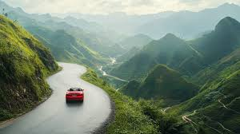

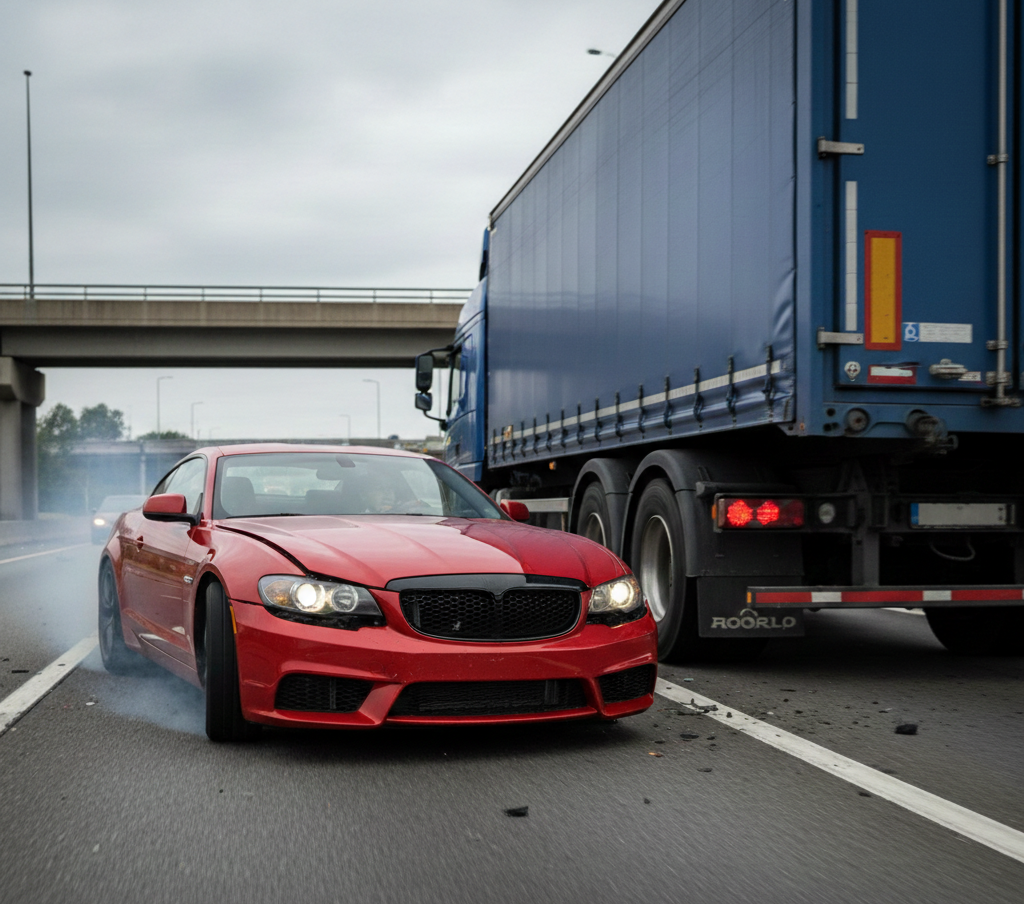

**Medium-term**

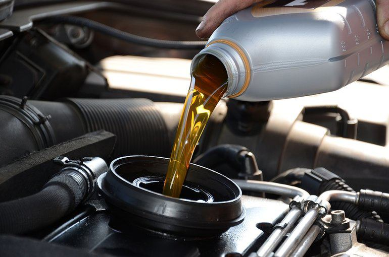

[figure not shown]

**Long-term**

[figure not shown]

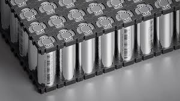

## ARPA-E NEXTCAR: Fuel Economy Optimization in CAVs

**Goal 1:** Optimize vehicle speed + powertrain dynamics with look-ahead information to minimize fuel consumption

- Target: **20%+ fuel economy improvement**
- Problem: **DP perturbed every 200 ms**

**Goal 2:** Futher optimize the HVAC energy consumption using look-ahead information

- Target: **10% HVAC energy improvement**
- Problem: **DP perturbed every 5 secs**

[figure not shown]

## Velocity Optimization using Look-ahead Information

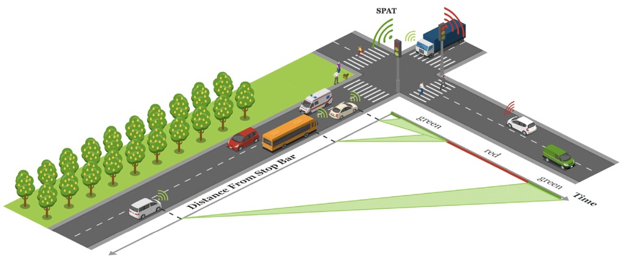

## How Are Changing Conditions Handled Today?

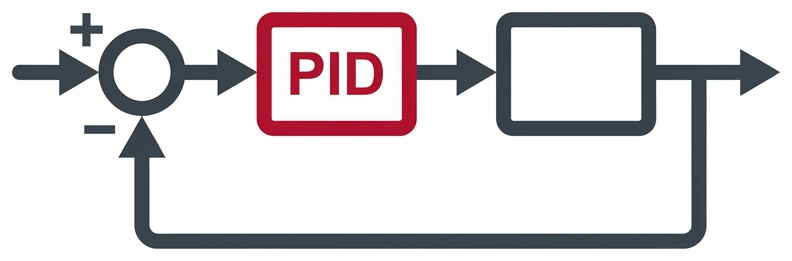

**PID**

Tuned at one point

[figure not shown]

**Robust Control**

Conservative

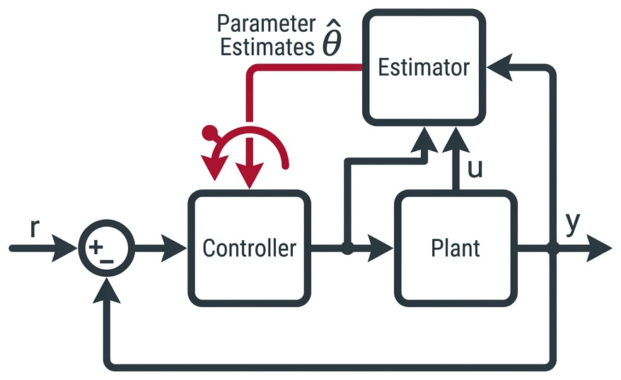

**Adaptive Control**

Slow, delicate stability

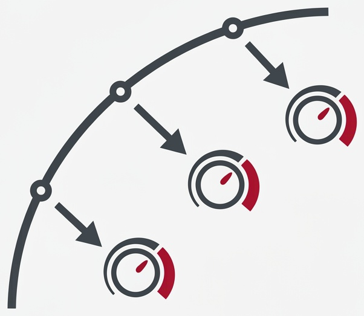

**Gain Scheduling**

Manual, offline tuning

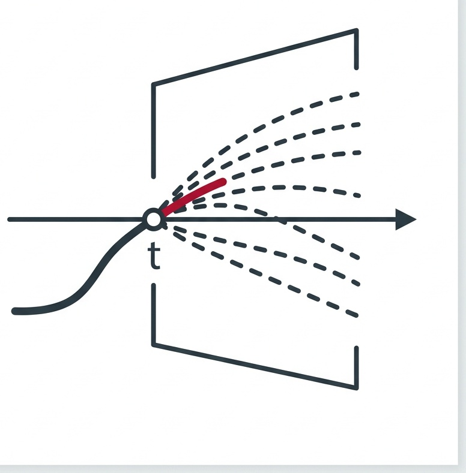

**MPC**

Re-solve every step

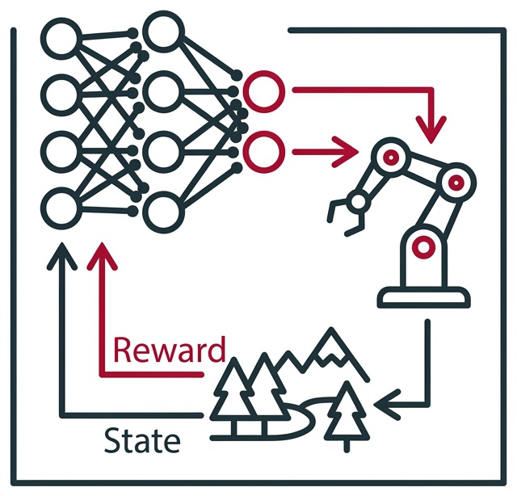

**Robust / Meta-RL**

Heavy retraining

## Markov Decision Process — A Primer

- **State space** $\mathcal{S}$
- **Action space** $\mathcal{A}$
- **Admissible pairs** $\mathcal{K}_t = \{(s,a): h_t(s,a) \leq 0\}$
- **Cost function** $c_t: \mathcal{K}_t \to \mathbb{R}$
- **Transition kernel** $P_t: \mathcal{K}_t \to \mathcal{P}(\mathcal{S})$
- **Policy** $\pi_t: \mathcal{S} \to \mathcal{A}$, with $\pi_t(s) \in \mathcal{K}_t(s)$

**Example: Eco-Driving**
$$\begin{aligned}
\min_{\text{Policy}} \quad & \text{Fuel Consumption + Driving time} \\
\text{subject to} \quad & \text{Vehicle Dynamics} \\
& \text{Safety Constraints}
\end{aligned}$$

Key Research Question

How can perturbation structure reduce the computational burden of recomputing optimal policy **by orders of magnitude?**

# Part II · Problem Formulation and Solution Approach

## MDP Performance Criterion

**Finite-horizon expected cost:**

$$J(\pi) = \mathbb{E}\!\left[c_{T+1}(s_{T+1}) + \sum_{t=0}^{T} c_t(s_t, a_t) \;\Bigg|\; a_t \sim \pi_t(\cdot|s_t),\; s_{t+1} \sim P_t(\cdot|s_t,a_t)\right]$$

**Dynamic Programming (Bellman equation):**

$$V_t(s_t) = \min_{a_t \in \mathcal{K}_t(s_t)} \left\{ c_t(s_t, a_t) + \mathbb{E}\!\left[V_{t+1}(s_{t+1})\right] \right\}, \qquad V_{T+1} = c_{T+1}$$

Solved by **backward induction** from $t = T$ to $t = 0$.

## A Model for Perturbations in MDPs

**Nominal MDP**

$$\mathcal{K}_t = \{h_t(s,a) \leq 0\}$$

$$\text{Cost: } c_t(s,a)$$

$$\text{Kernel: } P_t(ds'|s,a)$$

$$\text{Optimal: } \pi^*_t,\; V^*_t$$

**Perturbed MDP** *(small $\epsilon$)*

$$\widetilde{\mathcal{K}}_t = \{h_t(s,a) + \epsilon\widetilde{h}_t(s,a) \leq 0\}$$

$$\text{Cost: } c_t(s,a) + \epsilon\,\widetilde{c}_t(s,a)$$

$$\text{Kernel: } \widetilde{P}_t(ds'|s,a) \text{ (may also change)}$$

$$\text{Optimal: } \widetilde{\pi}^*_t,\; \widetilde{V}^*_t$$

Central Question

Given $\pi^*$ and $V^*$ from the **nominal** MDP (solved once):

- Do we have $\widetilde{\pi}^* \approx \pi^* + \epsilon\,d + o(\epsilon)$
- can we compute $d$ using simple computations

## Mathematical Formulation of Constrained Optimal Control Problem

**Nominal (deterministic) OCP:**

$$\min_{\{\pi_t\}} \;\; J(\pi) = c_{T+1}(s_{T+1}) + \sum_{t=0}^{T} c_t(s_t, a_t) \tag{cost $c$}$$

$$\text{subject to} \quad h_t(s_t, a_t) \leq 0, \qquad s_{t+1} = f_t(s_t, a_t) \tag{constraint $\mathcal{K}$, dynamics $P$}$$

**Perturbed OCP** — add $\epsilon$-scaled perturbation to cost and constraints:

$$\min_{\{\pi_t\}} \;\; J(\pi) + \epsilon\!\left(\widetilde{c}_{T+1}(s_{T+1}) + \sum_{t=0}^{T} \widetilde{c}_t(s_t,a_t)\right) \tag{cost $c + \epsilon\widetilde{c}$}$$

$$\text{s.t.} \quad h_t(s_t, a_t) + \epsilon\,\widetilde{h}_t \leq 0, \quad s_{t+1} = f_t(s_t, a_t) \tag{constraint $\widetilde{\mathcal{K}}$, dynamics unchanged}$$

*Connected to Neighboring Extremal Optimal Control (continuous time), iLQR/DDP/SAC (robotics).*

## Solving the Perturbed OCP

**Unperturbed Bellman:**
$$V_t(s_t) = \min_{a_t} \left\{c_t(s_t,a_t) + V_{t+1}(f_t(s_t,a_t))\right\} \quad \text{s.t.}\;\; h_t(s_t,a_t) \leq 0$$

**Perturbed Bellman** — expand $V^\epsilon_t = V_t + \epsilon\widetilde{V}_t + o(\epsilon)$:

$$V_t(s_t) + \epsilon\widetilde{V}_t(s_t) + o(\epsilon) = \min_{a_t} \Big\{
\underbrace{c_t + V_{t+1}\circ f_t}_{\text{nominal cost-to-go}} + \epsilon\underbrace{\Big(\widetilde{c}_t + \widetilde{V}_{t+1}\circ f_t\Big)}_{\text{first-order perturbation}}+ o(\epsilon)
\Big\} \quad \text{s.t.}\;\; h_t(s_t,a_t) + \epsilon\widetilde{h}_t \leq 0$$

**Separate $O(1)$ and $O(\epsilon)$ terms:**

- $O(1)$ → recovers original Bellman (trivially satisfied by $\pi^*$, $V^*$)
- $O(\epsilon)$ → a **single QP per time-step** for the correction $d_t(s)$, $\widetilde{V}_t(s)$

Ignore $o(\epsilon)$ term in the optimization

## Regularity Assumptions & Main Theorem

**A1 (Smoothness):** $c_t$, $h_t$ twice differentiable; $f_t$ differentiable; $V_t$ twice differentiable.

**A2 (LICQ):** Active-constraint Jacobian $A_t(s) := \bigl[\nabla_a h_{t,i}(s,\pi^*_t(s))\bigr]_{i \in \mathcal{A}(s)}$ is **full row rank** for all $s$.

**A3 (SOSC):** $\nabla^2_{aa}(c_t + V_{t+1}\circ f_t)(s,\pi^*_t(s)) \succ 0$ (positive definite).

**A4 (Strict Complementarity):** $\mu^*_{t,j}(s) > 0$ for all active constraints $j$.

Theorem — Differentiability of the Perturbed Optimal Policy

Under A1–A4, the optimal perturbed policy $\pi^\epsilon_t$ is **differentiable in $\epsilon$ at $\epsilon = 0$**, and

$$\boxed{\pi^\epsilon_t = \pi^*_t + \epsilon\,d_t + o(\epsilon)}$$

where the **correction direction** $d_t(s)$ is computable via a single QP.

*Proof:* Implicit Function Theorem applied to the KKT stationarity conditions.

## First-Order Perturbation: Quadratic Case

**Nominal QP**:
$$\min_{z \in \mathbb{R}^p} \;\frac{1}{2}z^\top H z + e^\top z \;\text{ s.t. }\; Az = b$$
$$\Rightarrow z^* = -H^{-1}(e + A^\top\kappa^*)$$
$$\kappa^* = -(AH^{-1}A^\top)^{-1}(AH^{-1}e+b)$$

**Perturbed QP:**
$$\min_z \;\frac{1}{2}z^\top(H+\epsilon\widetilde{H})z + (e+\epsilon\widetilde{e})^\top z$$
$$\text{ s.t. }\; Az = b + \epsilon\widetilde{b}$$

## First-Order Correction

**Taylor expansion of matrix inverse:**
$$(H+\epsilon\widetilde{H})^{-1} = H^{-1} - \epsilon\, H^{-1}\widetilde{H}H^{-1} + o(\epsilon)$$

**First-order correction:** If $z^* = 0$, then

$$\boxed{\widetilde{z}^\epsilon - z^* = \epsilon\, \underbrace{H^{-1}\!\begin{bmatrix} A^\top M A H^{-1} - I \;\big|\; A^\top M \end{bmatrix}\!\begin{bmatrix} \widetilde{e} \\ \widetilde{b} \end{bmatrix}}_{\text{Correction Direction: } d} + \underbrace{o(\epsilon)}_{\text{Negligible for small } \epsilon}}$$

$$\widetilde{\kappa}^\epsilon - \kappa^* = -\epsilon\, M\bigl(AH^{-1}\widetilde{e} + \widetilde{b}\bigr) + o(\epsilon)$$

where $M = (AH^{-1}A^\top)^{-1}$

Note: $\widetilde{z}^\epsilon$ is **differentiable in $\epsilon$** → consistent with main theorem.

## WASP Algorithm: Warm-Start DP

**Per-state quantities** (all evaluated at nominal optimum $\pi^*_t(s)$):

$$H(s) = \nabla^2_{aa} c_t(s,\pi^*_t(s)) + \nabla^2_{aa} (V_{t+1} \circ f_t)(s,\pi^*_t(s))$$

$$\widetilde{e}(s) = \nabla_a \widetilde{c}_t(s,\pi^*_t(s)) + \nabla_a (\widetilde{V}_{t+1} \circ f_t)(s,\pi^*_t(s))$$

$$A(s) = \bigl[\nabla_a h_{t,i}(s,\pi^*_t(s))^\top\bigr]_{i \in \text{active}}, \qquad \widetilde{b}(s) = -\bigl[\widetilde{h}_{t,i}\bigr]_{i \in \text{active}}$$

**WASP closed-form update:**

$$d_t(s) = H^{-1}\!\begin{bmatrix} A^\top M A H^{-1} - I \;\big|\; A^\top M \end{bmatrix}\!\begin{bmatrix} \widetilde{e}(s) \\ \widetilde{b}(s) \end{bmatrix}$$

$$\boxed{\widetilde{\pi}^*_t(s) \approx \pi^*_t(s) + \epsilon\,d_t(s)} \qquad \text{[policy update]}$$

$$\widetilde{V}_t(s) = \widetilde{c}_t(s,\pi^*_t(s)) + \nabla_a(c_t + V_{t+1}\circ f_t)^\top(s,\pi^*_t(s))\,d_t(s) \qquad \text{[value update]}$$

## Perturbations in Forecasts

**Physical systems have measurable (and forecastable) parameters $\theta_t$:**

$$\min_{\{a_t\}} \;\; \sum_{t=0}^T c_t(s_t, a_t, \theta_t) \quad\text{s.t.}\quad h_t(s_t, a_t, \theta_t) \leq 0,\;\; s_{t+1} = f_t(s_t, a_t, \theta_t)$$

**Perturbed problem** — parameter shifts by $\delta\theta_t$ (forecast update):

$$\min_{\{a_t\}} \;\; \sum_{t=0}^T c_t(s_t, a_t, \theta_t + \delta\theta_t) \quad\text{s.t.}\quad h_t(s_t, a_t, \theta_t + \delta\theta_t) \leq 0,\;\; s_{t+1} = f_t(s_t, a_t, \theta_t + \delta\theta_t)$$

**WASP for parametrized OCP** — define:

$$\widetilde{c}_t(s,a) = \nabla_\theta c_t(s,a,\theta_t)\cdot\delta\theta_t, \quad \widetilde{h}_t(s,a) = \nabla_\theta h_t(s,a,\theta_t)\cdot\delta\theta_t, \quad \widetilde{f}_t(s,a) = \nabla_\theta f_t(s,a,\theta_t)\cdot\delta\theta_t$$

A similar WASP formula applies — **perturbation in parameters maps to perturbation in cost/constraints/dynamics.**

# Part III · Results & Applications

## Simulation Results: Velocity Tracking ($\epsilon$ = 0.1)

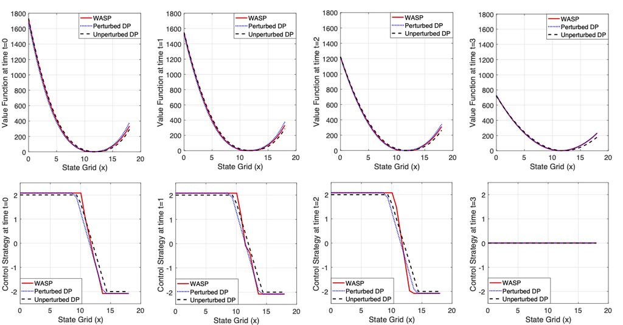

## Simulation Results: Significant Constraint Perturbations ($\epsilon$ = 1.0)

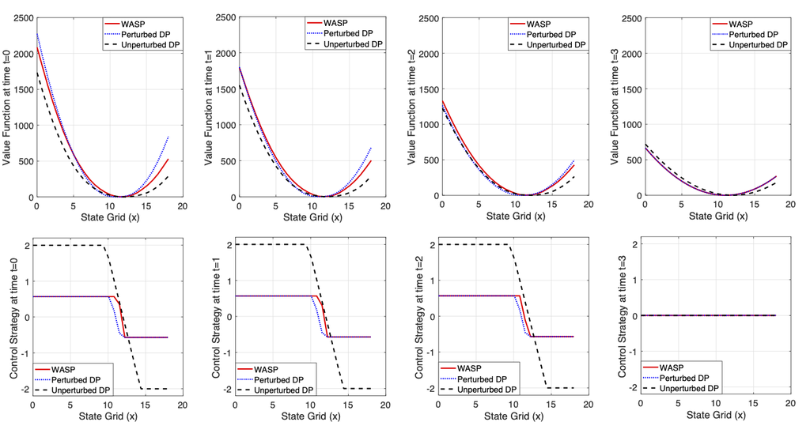

## Computational Speedup Due to WASP

[interactive chart not shown]

*WASP alone: **79.1% faster** than baseline · Used as warm-start: additional 14.6% · Real-time deployment: **50 ms** (within automotive requirements)*

## ARPA-E NEXTCAR: Fuel Economy Optimization in CAVs

**Goal:** Optimize vehicle speed + powertrain dynamics with look-ahead information to minimize fuel consumption

- WASP made velocity optimization and air conditioning optimization real-time feasible

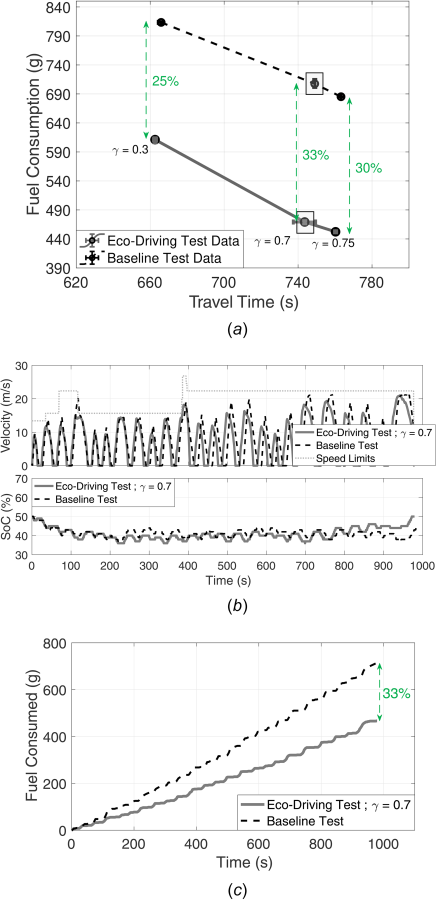

[figure not shown]

## WASP for Thermal Management in EVs

**Goal:** Optimize compressor speed and fan air flow to minimize energy in EV thermal management — with look-ahead on vehicle speed, ambient temperature, and passenger demand

**Various perturbations tested:**

[figure not shown]

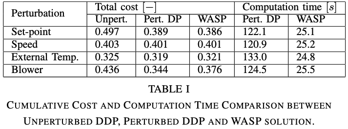

## Results: WASP for Thermal Management in EVs

**Goal:** Optimize compressor speed and fan air flow to minimize energy in EV thermal management — with look-ahead on vehicle speed, ambient temperature, and passenger demand

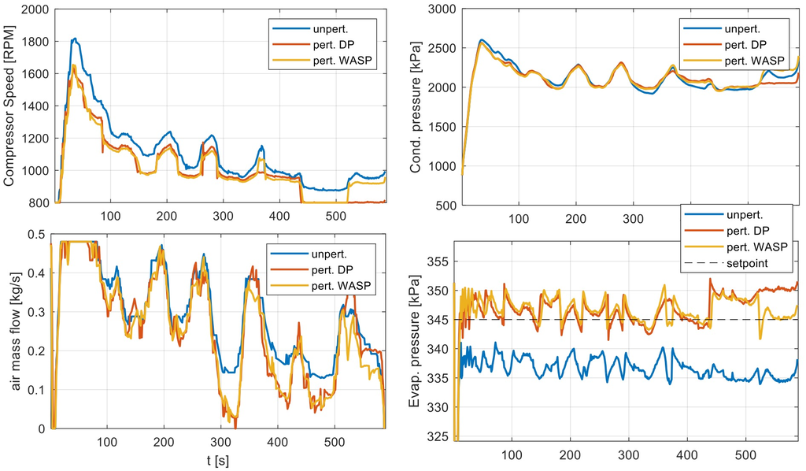

# Part V · Ongoing Work

## Applications: Material Discovery or Fluid Flow Control

**Solid Electrolyte Discovery**

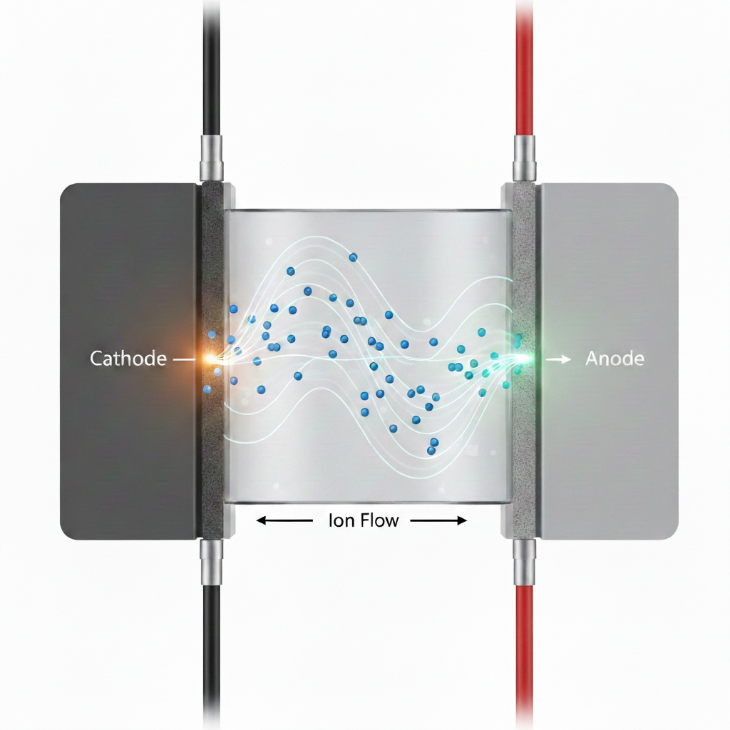

RL agent explores composition space guided by perturbation-theoretic policy updates

**Aerodynamic Drag Reduction**

[figure not shown]

Active flow control over vehicle surfaces — continuous perturbation in flow boundary conditions

## RL for General MDPs: New Policy Gradient Algorithm

### Joint work with Prof. Aditya Mahajan

**Key insight:** Perturbation framework extends to **general MDPs** via functional analysis

- State and action spaces are Polish spaces
- Policy space is viewed as the space of linear operators
- First-order correction in $\pi$ gives a new **PPO/TRPO-style update rule**
- Exploits problem structure

Connection to Existing RL

The WASP direction $d_t(s)$ is analogous to the **policy gradient** — but derived from **perturbation theory**

## Summary

**1. Perturbation Model**  
For MDPs and constrained OCPs

**3. NEXTCAR Implementation**  
Velocity & thermal optimization for improving energy efficiency

**4. New RL Algorithms**  
For infinite-dimensional MDPs

## My lectures on YouTube

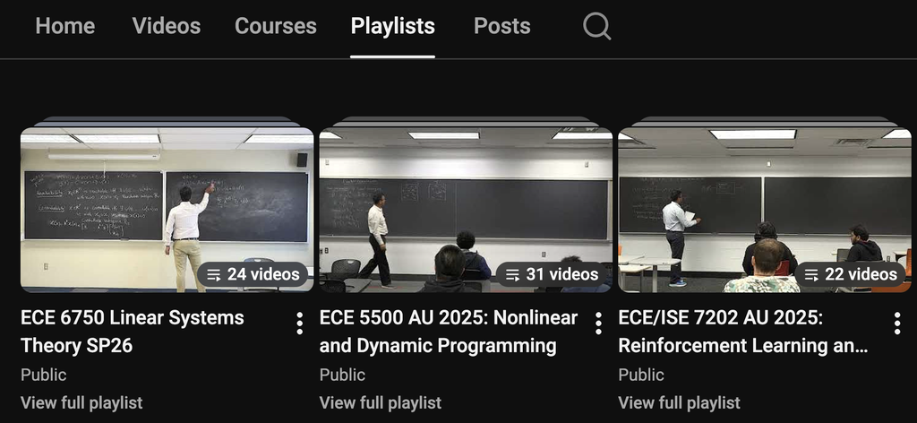